# Taller 1: Estadistica descriptiva

Maria Camila Gómez, Miguel Angel Pastor

octubre de 2018

# Base de datos papa

## Planteamiento del problema

El cultivo de la papa ha tenido grandes problematicas ambientales, pues éste, por ser un cultivo perteneciente a la famila de las solanaceas, y por tener una larga trayectoria en su produccion, es muy suceptible a plagas y enfermedades ya que estas van generando resistencia a los diferentes productos que se aplican para su control; debido a esto se hace necesario la aplicacion de gran cantidad de insumos para su producción sin darle gran importancia a al impacto ambiental que se genera. A pesar de que la papa puede dar produccion desde los 0 msnm hasta los propios paramos para disminuir el ataque por plagas y enfermedades los agricultores prefieren cultivarla en zonas altas como paramos o cercanas a los paramos. Es aca donde se genera la gran problematica de este cultivo principalmente a nivel ambiental ya que cuando se afecta el medio ambiente con aplicacion de productos para el control de plagas y enfermedades, tambien se destruye no de los ecosistemas mas imprtantes de la tierra como los paramos o zonas aledañas que proveen el recurso mas importante para la vida como lo es el recurso hidrico.

## Preguntas de interes con respecto a los datos

```r
# Cultivo de papa
papa <- read.csv("Cadena_Productiva_Papa_-_Area__Producci_n_Y_Rendimiento.csv",
                 encoding = "UTF-8")
head(papa)
```

|  | CÓD..DEP. | DEPARTAMENTO | CÓD..MUN. | MUNICIPIO | GRUPO.DE.CULTIVO | SUBGRUPO.DE.CULTIVO | CULTIVO | DESAGREGACIÓN.REGIONAL.Y.O.SISTEMA.PRODUCTIVO | CÓDIGO.CULTIVO | NOMBRE.CIENTIFICO | PERIODO | Área.Sembrada.ha. | Área.Cosechada.ha. | Producción.t. | Rendimiento.t.ha. | ESTADO.FISICO.PRODUCCION |
| --- | --- | --- | --- | --- | --- | --- | --- | --- | --- | --- | --- | --- | --- | --- | --- | --- |
| 1 | 5 | ANTIOQUIA | 5674 | SAN VICENTE | TUBERCULOS Y PLATANOS | PAPA | PAPA | PAPA | 111041190320 | SOLANUM TUBEROSUM | 2006B | 1400 | 1400 | 25200 | 18 | TUBERCULO FRESCO |
| 2 | 5 | ANTIOQUIA | 5148 | CARMEN DE VIBORAL | TUBERCULOS Y PLATANOS | PAPA | PAPA | PAPA | 111041190320 | SOLANUM TUBEROSUM | 2006B | 900 | 870 | 12180 | 14 | TUBERCULO FRESCO |
| 3 | 5 | ANTIOQUIA | 5400 | LA UNION | TUBERCULOS Y PLATANOS | PAPA | PAPA | PAPA | 111041190320 | SOLANUM TUBEROSUM | 2006B | 709 | 709 | 12053 | 17 | TUBERCULO FRESCO |
| 4 | 5 | ANTIOQUIA | 5664 | SAN PEDRO | TUBERCULOS Y PLATANOS | PAPA | PAPA | PAPA | 111041190320 | SOLANUM TUBEROSUM | 2006B | 652 | 652 | 14344 | 22 | TUBERCULO FRESCO |
| 5 | 5 | ANTIOQUIA | 5440 | MARINILLA | TUBERCULOS Y PLATANOS | PAPA | PAPA | PAPA | 111041190320 | SOLANUM TUBEROSUM | 2006B | 570 | 570 | 8550 | 15 | TUBERCULO FRESCO |
| 6 | 5 | ANTIOQUIA | 5002 | ABEJORRAL | TUBERCULOS Y PLATANOS | PAPA | PAPA | PAPA | 111041190320 | SOLANUM TUBEROSUM | 2006B | 550 | 550 | 8800 | 16 | TUBERCULO FRESCO |

```r
str(papa)
```

```
## 'data.frame':    6765 obs. of  16 variables:
##  $ CÓD..DEP.                                    : int  5 5 5 5 5 5 5 5 5 5 ...
##  $ DEPARTAMENTO                                 : Factor w/ 18 levels "ANTIOQUIA","BOYACA",..: 1 1 1 1 1 1 1 1 1 1 ...
##  $ CÓD..MUN.                                    : int  5674 5148 5400 5664 5440 5002 5686 5697 5264 5086 ...
##  $ MUNICIPIO                                    : Factor w/ 312 levels "ABEJORRAL","AGUADA",..: 231 38 146 228 160 1 235 241 85 18 ...
##  $ GRUPO.DE.CULTIVO                             : Factor w/ 1 level "TUBERCULOS Y PLATANOS": 1 1 1 1 1 1 1 1 1 1 ...
##  $ SUBGRUPO.DE.CULTIVO                          : Factor w/ 1 level "PAPA": 1 1 1 1 1 1 1 1 1 1 ...
##  $ CULTIVO                                      : Factor w/ 1 level "PAPA": 1 1 1 1 1 1 1 1 1 1 ...
##  $ DESAGREGACIÓN.REGIONAL.Y.O.SISTEMA.PRODUCTIVO: Factor w/ 2 levels "PAPA","PAPA CRIOLLA": 1 1 1 1 1 1 1 1 1 1 ...
##  $ CÓDIGO.CULTIVO                               : num  1.11e+11 1.11e+11 1.11e+11 1.11e+11 1.11e+11 ...
##  $ NOMBRE.CIENTIFICO                            : Factor w/ 1 level "SOLANUM TUBEROSUM": 1 1 1 1 1 1 1 1 1 1 ...
##  $ PERIODO                                      : Factor w/ 22 levels "2006B","2007A",..: 1 1 1 1 1 1 1 1 1 1 ...
##  $ Área.Sembrada.ha.                            : int  1400 900 709 652 570 550 540 500 480 200 ...
##  $ Área.Cosechada.ha.                           : int  1400 870 709 652 570 550 540 480 480 200 ...
##  $ Producción.t.                                : int  25200 12180 12053 14344 8550 8800 9450 7680 10560 5000 ...
##  $ Rendimiento.t.ha.                            : num  18 14 17 22 15 16 17.5 16 22 25 ...
##  $ ESTADO.FISICO.PRODUCCION                     : Factor w/ 1 level "TUBERCULO FRESCO": 1 1 1 1 1 1 1 1 1 1 ...
```

```r
papa1 <- papa [, c("DEPARTAMENTO", "MUNICIPIO", "PERIODO", "Área.Sembrada.ha.", "Área.Cosechada.ha.", "Rendimiento.t.ha.", "Producción.t.")]

head(papa1)
```

|  | DEPARTAMENTO | MUNICIPIO | PERIODO | Área.Sembrada.ha. | Área.Cosechada.ha. | Rendimiento.t.ha. | Producción.t. |
| --- | --- | --- | --- | --- | --- | --- | --- |
| 1 | ANTIOQUIA | SAN VICENTE | 2006B | 1400 | 1400 | 18 | 25200 |
| 2 | ANTIOQUIA | CARMEN DE VIBORAL | 2006B | 900 | 870 | 14 | 12180 |
| 3 | ANTIOQUIA | LA UNION | 2006B | 709 | 709 | 17 | 12053 |
| 4 | ANTIOQUIA | SAN PEDRO | 2006B | 652 | 652 | 22 | 14344 |
| 5 | ANTIOQUIA | MARINILLA | 2006B | 570 | 570 | 15 | 8550 |
| 6 | ANTIOQUIA | ABEJORRAL | 2006B | 550 | 550 | 16 | 8800 |

```r
summary(papa1)
```

```
##              DEPARTAMENTO       MUNICIPIO       PERIODO
##  BOYACA            :2011   GRANADA   :  64   2017A  : 354
##  CUNDINAMARCA      :1606   BELEN     :  54   2016A  : 347
##  NARIÑO            : 928   BOLIVAR   :  53   2015A  : 346
##  ANTIOQUIA         : 712   CONCEPCION:  49   2013A  : 343
##  SANTANDER         : 400   CORDOBA   :  46   2010A  : 332
##  NORTE DE SANTANDER: 256   CALDAS    :  45   2014A  : 332
##  (Other)           : 852   (Other)   :6454   (Other):4711
##  Área.Sembrada.ha. Área.Cosechada.ha. Rendimiento.t.ha. Producción.t.
##  Min.   :   0.0    Min.   :   0.0     Min.   : 0.30     Min.   :     0
##  1st Qu.:  20.0    1st Qu.:  18.0     1st Qu.:10.50     1st Qu.:   206
##  Median :  72.0    Median :  70.0     Median :15.00     Median :  1000
##  Mean   : 281.3    Mean   : 265.6     Mean   :15.19     Mean   :  5060
##  3rd Qu.: 300.0    3rd Qu.: 270.0     3rd Qu.:19.00     3rd Qu.:  4488
##  Max.   :9924.0    Max.   :9877.0     Max.   :46.00     Max.   :281779
##                                       NA's   :8
```

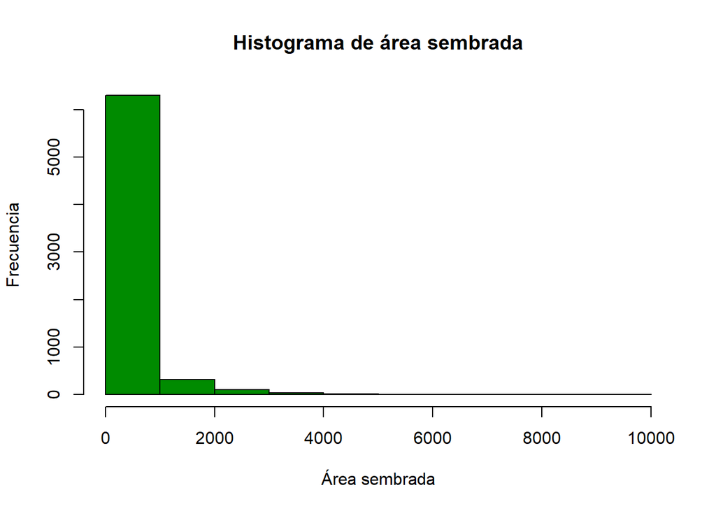

```r
hist(papa1$Área.Sembrada.ha., main = paste("Histograma de área sembrada"), xlab = "Área sembrada", ylab = "Frecuencia", col = "green4")
```

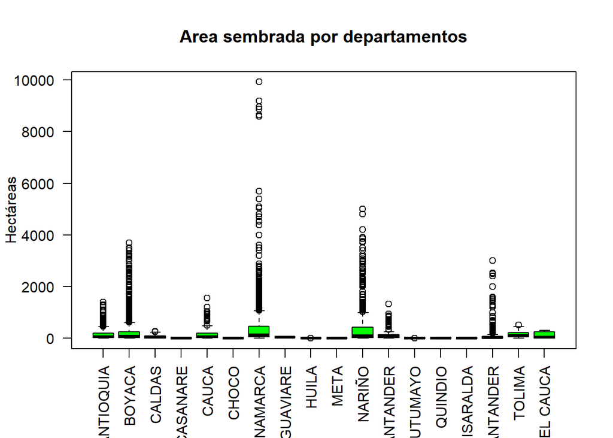

```r
boxplot(papa1$Área.Sembrada.ha. ~ papa1$DEPARTAMENTO,
        main = "Area sembrada por departamentos",
        xlab = " ",
        ylab = "Hectáreas",
        col = "green", las= 2)
```

```r
tapply(papa1$Área.Sembrada.ha., papa1$DEPARTAMENTO,mean)
```

```
##          ANTIOQUIA             BOYACA             CALDAS
##         168.264045         261.201890          63.256198
##           CASANARE              CAUCA              CHOCO
##          10.333333         155.218107           2.833333
##       CUNDINAMARCA           GUAVIARE              HUILA
##         440.341843          38.000000           4.286765
##               META             NARIÑO NORTE DE SANTANDER
##           1.000000         393.188578         157.726562
##           PUTUMAYO            QUINDIO          RISARALDA
##           6.174603           5.166667           5.000000
##          SANTANDER             TOLIMA    VALLE DEL CAUCA
##         158.070000         155.264706         123.121212
```

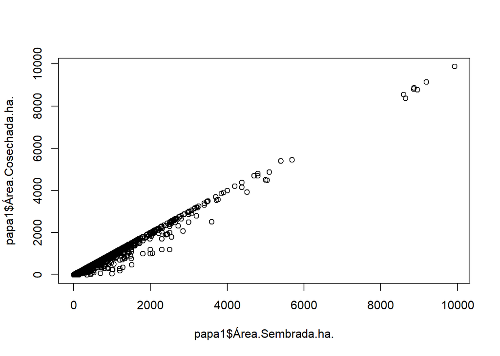

```r
plot(papa1$Área.Sembrada.ha., papa1$Área.Cosechada.ha.)
```

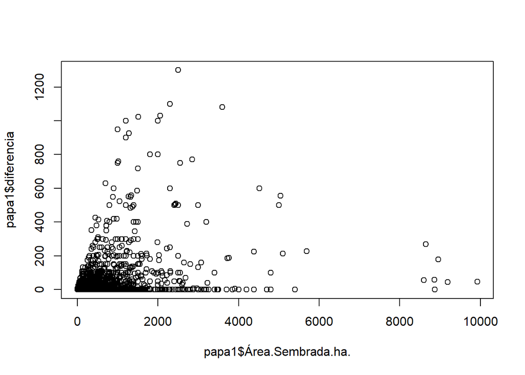

```r
papa1$diferencia <- papa1$Área.Sembrada.ha. - papa1$Área.Cosechada.ha.


plot(papa1$Área.Sembrada.ha., papa1$diferencia)
```